# Biking in the Rain: An Analysis of Temperature on the Bikeshare Business with ARIMA

## 1.6 Model Fitting and Assessment

### 1.6.1 Durbin-Watson Test

We are finally ready to check for the presence of serial correlation using Durbin-Watson test

```r
suppressPackageStartupMessages(library(car))
durbinWatsonTest(DTBikeShare)
```

```
##  lag Autocorrelation D-W Statistic p-value
##    1       0.4241107      1.150287       0
##  Alternative hypothesis: rho != 0
```

Yes, the ACF and PACF presence and the autocorrelation inherent warrants an ARIMA.

### 1.6.2 ACF and PACF

```r
par(mfrow=c(1,2))

plot = c(1,2)
ACF<-Acf(registered.ts, lag.max = length(registered.ts))
ACF
```

```
##
## Autocorrelations of series 'registered.ts', by lag
##
##      0      1      2      3      4      5      6      7      8      9     10
##  1.000  0.260  0.031  0.098  0.093  0.087  0.261  0.300  0.110  0.113 -0.026
##     11     12     13     14     15     16     17     18     19     20     21
##  0.110 -0.013  0.057  0.287  0.211 -0.064 -0.031  0.092 -0.040  0.094  0.221
##     22     23     24     25     26     27     28     29     30     31     32
##  0.092 -0.024 -0.028 -0.106 -0.032  0.078  0.106  0.084 -0.147 -0.126  0.036
##     33     34     35     36     37     38     39     40     41     42     43
## -0.003 -0.032  0.133 -0.017 -0.190 -0.020 -0.042 -0.112  0.047  0.128  0.043
##     44     45     46     47     48     49     50     51     52     53     54
## -0.071 -0.151 -0.069 -0.049 -0.004  0.089  0.047 -0.138 -0.093  0.011 -0.058
##     55     56     57     58     59     60     61     62     63     64     65
## -0.001  0.078  0.050 -0.163 -0.091 -0.021 -0.047 -0.020 -0.067 -0.040 -0.161
##     66     67     68     69     70     71     72     73     74     75     76
## -0.142 -0.095 -0.060 -0.078  0.021  0.024 -0.208 -0.103 -0.050  0.022 -0.072
##     77     78     79     80     81     82     83     84     85     86     87
## -0.008 -0.103 -0.104 -0.090 -0.086 -0.052 -0.064  0.037 -0.010 -0.060 -0.136
##     88     89     90     91     92     93     94     95     96     97     98
## -0.036 -0.016 -0.029  0.007  0.020 -0.014 -0.045 -0.031 -0.050 -0.027  0.017
##     99    100    101    102    103
##  0.022 -0.006 -0.025 -0.015 -0.004
```

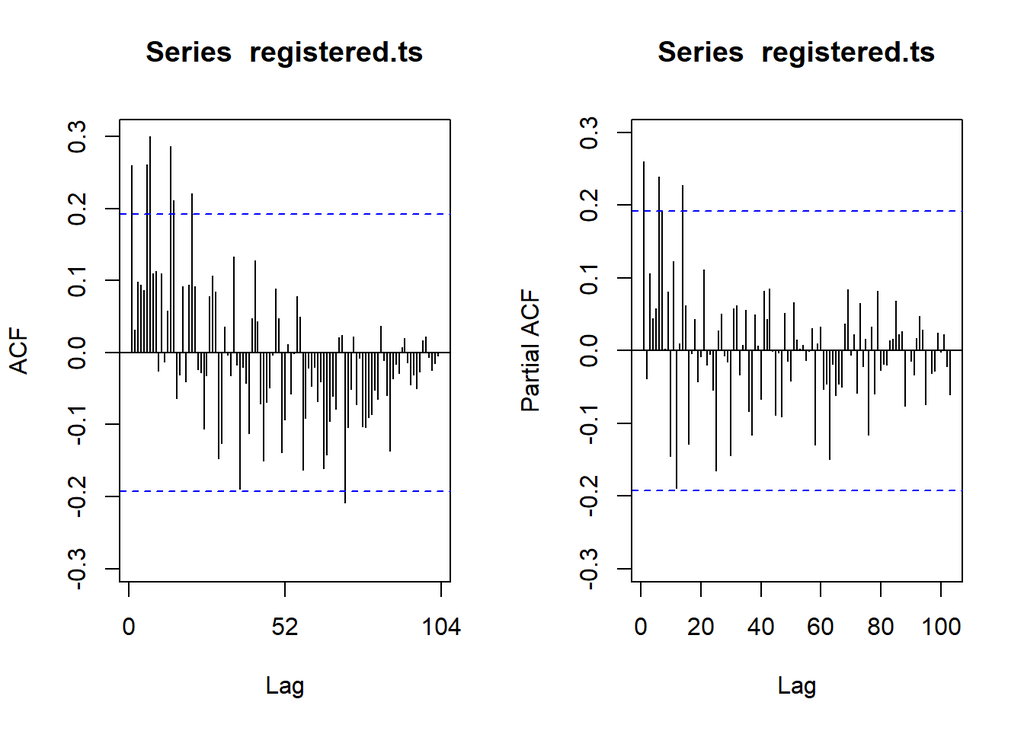

```r
PACF<-Pacf(registered.ts, lag.max = length(registered.ts))
```

```r
PACF
```

```
##
## Partial autocorrelations of series 'registered.ts', by lag
##
##      1      2      3      4      5      6      7      8      9     10     11
##  0.260 -0.038  0.106  0.045  0.058  0.239  0.193  0.003  0.081 -0.145  0.123
##     12     13     14     15     16     17     18     19     20     21     22
## -0.190  0.010  0.228  0.062 -0.129 -0.004  0.043 -0.043 -0.008  0.111 -0.020
##     23     24     25     26     27     28     29     30     31     32     33
## -0.005 -0.054 -0.165  0.027  0.050 -0.007 -0.015 -0.144  0.058  0.062 -0.033
##     34     35     36     37     38     39     40     41     42     43     44
##  0.008  0.055 -0.083 -0.116  0.049  0.007 -0.066  0.082  0.043  0.085 -0.001
##     45     46     47     48     49     50     51     52     53     54     55
## -0.089 -0.002 -0.091  0.052 -0.015 -0.042  0.066  0.015  0.002  0.008 -0.013
##     56     57     58     59     60     61     62     63     64     65     66
##  0.000  0.030 -0.130  0.009  0.033 -0.053 -0.046 -0.150 -0.019 -0.061 -0.046
##     67     68     69     70     71     72     73     74     75     76     77
## -0.049  0.037  0.084 -0.006  0.023 -0.058  0.065 -0.022  0.016 -0.116  0.033
##     78     79     80     81     82     83     84     85     86     87     88
## -0.059  0.082 -0.027 -0.019 -0.020  0.014  0.016  0.068  0.022  0.027 -0.076
##     89     90     91     92     93     94     95     96     97     98     99
##  0.001 -0.015 -0.033  0.017  0.048  0.028 -0.074  0.001 -0.031 -0.028  0.025
##    100    101    102    103
## -0.002  0.022 -0.022 -0.060
```

The lags, once again, match with the number of weeks that we’re analyzing.

### 1.6.3 ARIMA

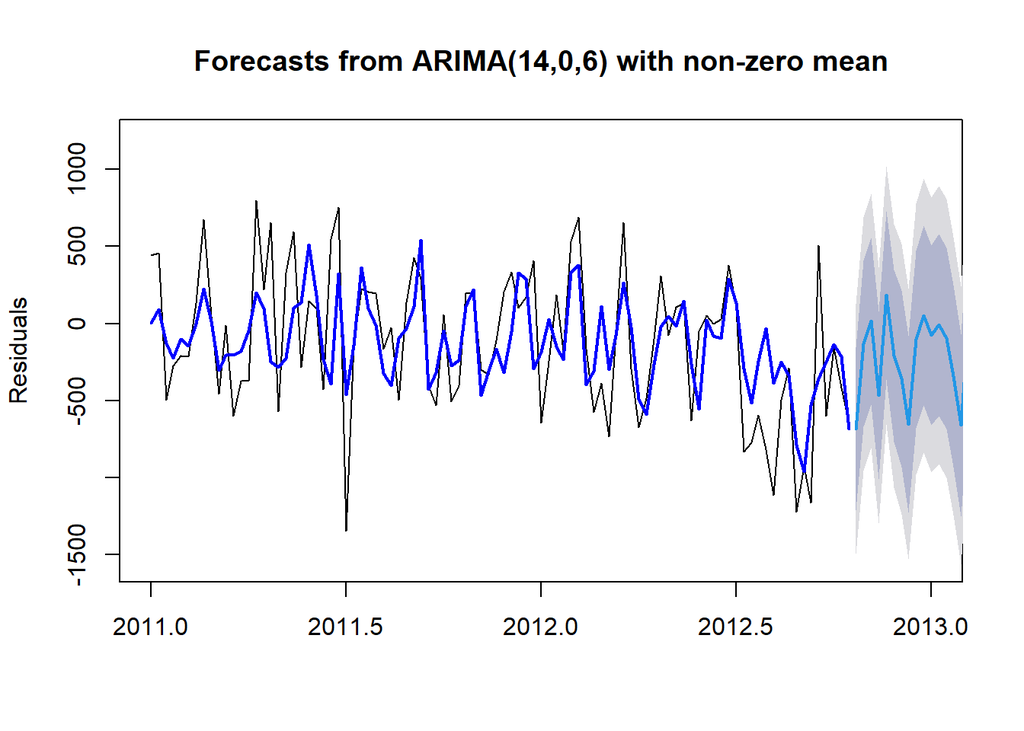

```r
reg_resids <- train.ts
train.res.arima <- Arima(reg_resids, order = c(14,0,6))
train.res.arima.pred <- forecast(train.res.arima, h = nValid)

# Set the plot limits
plot(train.res.arima.pred, xlim = c(2011, 2013),
     main = "Forecasts from ARIMA(14,0,6) with non-zero mean", ylab = "Residuals")

lines(train.res.arima.pred$fitted, lwd = 2, col = "blue")
lines(train.lm.trend.season, lwd = 2, col = "gray")
```

Here, in our forecast, we can see that the model, the blue line, seems to predict our actual `registered` value swell. We can see that he blue line is affected by the mean of the actual model, meaning that the noise is diminished in the model. We can also see that the forecasted data seems to be dipping downwards along with everything after 2012.5.

In the actual dataset, the model touches the very bottom prediction interval of the forecast which is a little concerning accuracy-wise.

We must run ACF and PACF again to see if there are more AR or MA components:

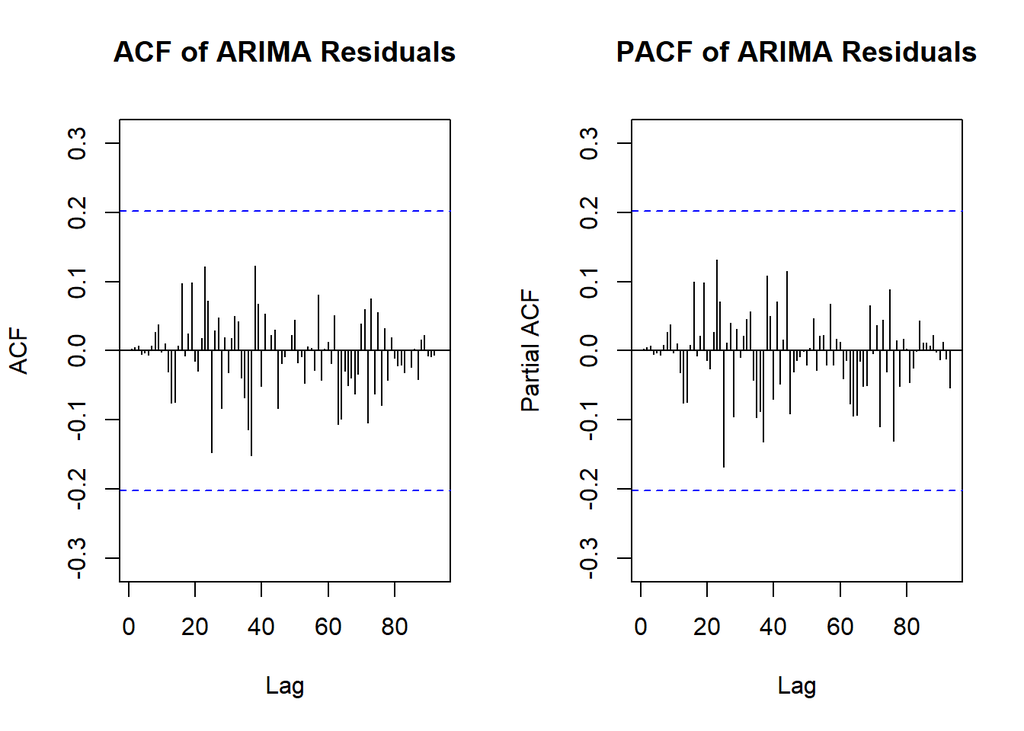

```r
par(mfrow=c(1,2))


# Extract the residuals from the ARIMA model
arima_residuals <- residuals(train.res.arima)

# Plot the ACF of the ARIMA residuals
Acf(arima_residuals, main = "ACF of ARIMA Residuals")

# Plot the PACF of the ARIMA residuals
Pacf(arima_residuals, main = "PACF of ARIMA Residuals")
```

As we can see, there are no more AR/MA components, and our model is final.

## 1.7 Model Interpretation

In the context of our business problem, we can see that AR/MA components are predictable to a certain extent, and that it’s possible to develop a model from this data. Essentially, the number of registered users on one day will always affect the number of registered users on another day. We can also see that if we want to test correlation and thus AR/MA elements on a different variable in the dataset, like thinking about how holiday or non-holiday affects registered users, we could.

**From a business perspective,** this makes sense. If a business service is popular for one week, it will likely affect the popularity of the following week. In this case, popularity is the number of registered users. It also makes sense that consumer demand (or the count of registered users) would decrease when a product may exert some discomfort on the user, like being cold.

Thinking about Washington D.C. in this context, the weather doesn’t get too warm there, so it also makes sense that super hot weather doesn’t exert any discomfort either.

## 1.8 Prediction and Forecasting

### 1.8.1 Short-Term

[figure not shown]

```r
#changing the end to 2012, 48 to make it short
shorttrain.ts <- ts(registered.ts, start = c(2011, 1), end = c(2012, 48), freq = 52)

shortvalid.ts <- ts(registered.ts, start = c(2012, 43), end = c(2012, 52), freq = 52)

# Converting the training time series to a time series object with frequency 52
shorttrain.lm.trend.season <- ts(train.ts, freq = 52)

reg_resids <- shorttrain.ts
shorttrain.res.arima <- Arima(reg_resids, order = c(14,0,6))
shorttrain.res.arima.pred <- forecast(shorttrain.res.arima, h = nValid)

# Setting the plot limits
plot(shorttrain.res.arima.pred, xlim = c(2011, 2013),
     main = "Forecasts from ARIMA(3,0,3) with non-zero mean", ylab = "Residuals")

lines(shorttrain.res.arima.pred$fitted, lwd = 2, col = "blue")
lines(shorttrain.lm.trend.season, lwd = 2, col = "gray")
```

Here, we can see a prediction that seems on-par with our fisst prediction and continues on the downward trend.

### 1.8.2 Long-Term

[figure not shown]

```r
#changing the end to 2012, 26 to make it long

longtrain.ts <- ts(registered.ts, start = c(2011, 1), end = c(2012, 26), freq = 52)

longvalid.ts <- ts(registered.ts, start = c(2012, 27), end = c(2012, 52), freq = 52)


longtrain.lm.trend.season <- ts(longtrain.ts, freq = 52)

reg_resids <- longtrain.ts
longtrain.res.arima <- Arima(reg_resids, order = c(14,0,6))
longtrain.res.arima.pred <- forecast(longtrain.res.arima, h = nValid)


plot(longtrain.res.arima.pred, xlim = c(2011, 2013),
     main = "Forecasts from ARIMA(3,0,3) with non-zero mean", ylab = "Residuals")

lines(longtrain.res.arima.pred$fitted, lwd = 2, col = "blue")
lines(longtrain.lm.trend.season, lwd = 2, col = "gray")
```

This is quite concerning The model looks really similar in the forecastng as it does when it’s on the actual model suggesting that it’s not being thorough with picking up on nuances. The longer time frame for the forecast means less training data. This all in all decreases accuracy as you can see by not having a nuanced forecast.

## 1.9 Business Insights

### 1.9.1 Insights

1. Bikesharing is more popular with registered users in Washington D.C. in the summer and spring months.
2. Washington D.C. has nice weather during the spring/summer months - perfect for biking.
3. There is an AR/MA component within registered users that Capital Bikeshare should keep in mind when thinking about weekly increases/decreases in registered users. More specifically, what exactly caused this increase/decrease from last week’s registered users to this week’s?

### 1.9.2 Recommendations

1. Market more during warmer months like summer and spring. This is when the registered user count is higher. People desire bikesharing services more in the summer and spring
2. Market to college students who have summer internships in washington D.C.
3. Pair up with companies that offer these internships during the summer months to offer discounts to students in the summer to incentivize more subscriptions and encourage use after the internship as well.
4. Perform statistical analysis on more variables within the dataset.
5. Improve supply chain to allocate more resources during the warmer months.
6. Predict revenues and risks based on weather models.